# Optimal Treatment Analysis

## Outcome Variable

**Outcome Variable:** whz

## Predictor Variables

**Intervention Variable:** earlybf

**Adjustment Set:**

- arm
- sex
- W_mage
- meducyrs
- feducyrs
- hhwealth_quart
- hfoodsec
- W_mhtcm
- W_mwtkg
- W_mbmi
- vagbrth
- W_gagebrth
- W_birthwt
- W_birthlen
- W_nrooms
- W_nchldlt5
- brthmon
- W_parity
- impfloor
- impsan
- safeh20
- delta_W_mage
- delta_meducyrs
- delta_feducyrs
- delta_hhwealth_quart
- delta_hfoodsec
- delta_W_mhtcm
- delta_W_mwtkg
- delta_W_mbmi
- delta_vagbrth
- delta_W_gagebrth
- delta_W_birthwt
- delta_W_birthlen
- delta_W_nrooms
- delta_W_nchldlt5
- delta_brthmon
- delta_W_parity
- delta_impfloor
- delta_impsan
- delta_safeh20

## Stratifying Variables

The analysis was stratified on these variable(s):

- agecat
- studyid
- country

## Data Summary

| agecat | studyid | country | earlybf | n_cell | n |
| --- | --- | --- | --- | --- | --- |
| Birth | EE | PAKISTAN | 1 | 36 | 170 |
| Birth | EE | PAKISTAN | 0 | 134 | 170 |
| Birth | GMS-Nepal | NEPAL | 1 | 171 | 586 |
| Birth | GMS-Nepal | NEPAL | 0 | 415 | 586 |
| Birth | JiVitA-3 | BANGLADESH | 1 | 105 | 17943 |
| Birth | JiVitA-3 | BANGLADESH | 0 | 17838 | 17943 |
| Birth | JiVitA-4 | BANGLADESH | 1 | 1624 | 2396 |
| Birth | JiVitA-4 | BANGLADESH | 0 | 772 | 2396 |
| Birth | MAL-ED | BANGLADESH | 1 | 140 | 214 |
| Birth | MAL-ED | BANGLADESH | 0 | 74 | 214 |
| Birth | MAL-ED | BRAZIL | 1 | 26 | 62 |
| Birth | MAL-ED | BRAZIL | 0 | 36 | 62 |
| Birth | MAL-ED | INDIA | 1 | 31 | 44 |
| Birth | MAL-ED | INDIA | 0 | 13 | 44 |
| Birth | MAL-ED | NEPAL | 1 | 14 | 26 |
| Birth | MAL-ED | NEPAL | 0 | 12 | 26 |
| Birth | MAL-ED | PERU | 1 | 172 | 228 |
| Birth | MAL-ED | PERU | 0 | 56 | 228 |
| Birth | MAL-ED | SOUTH AFRICA | 1 | 69 | 110 |
| Birth | MAL-ED | SOUTH AFRICA | 0 | 41 | 110 |
| Birth | MAL-ED | TANZANIA, UNITED REPUBLIC OF | 1 | 103 | 115 |
| Birth | MAL-ED | TANZANIA, UNITED REPUBLIC OF | 0 | 12 | 115 |
| Birth | NIH-Crypto | BANGLADESH | 1 | 613 | 707 |
| Birth | NIH-Crypto | BANGLADESH | 0 | 94 | 707 |
| Birth | SAS-CompFeed | INDIA | 1 | 79 | 1072 |
| Birth | SAS-CompFeed | INDIA | 0 | 993 | 1072 |
| Birth | ZVITAMBO | ZIMBABWE | 1 | 6142 | 11514 |
| Birth | ZVITAMBO | ZIMBABWE | 0 | 5372 | 11514 |
| 6 months | EE | PAKISTAN | 1 | 69 | 364 |
| 6 months | EE | PAKISTAN | 0 | 295 | 364 |

[output cut: 52 more lines]

The following strata were considered:

- agecat: 24 months, studyid: EE, country: PAKISTAN
- agecat: 24 months, studyid: GMS-Nepal, country: NEPAL
- agecat: 24 months, studyid: JiVitA-3, country: BANGLADESH
- agecat: 24 months, studyid: JiVitA-4, country: BANGLADESH
- agecat: 24 months, studyid: MAL-ED, country: BANGLADESH
- agecat: 24 months, studyid: MAL-ED, country: BRAZIL
- agecat: 24 months, studyid: MAL-ED, country: INDIA
- agecat: 24 months, studyid: MAL-ED, country: NEPAL
- agecat: 24 months, studyid: MAL-ED, country: PERU
- agecat: 24 months, studyid: MAL-ED, country: SOUTH AFRICA
- agecat: 24 months, studyid: MAL-ED, country: TANZANIA, UNITED REPUBLIC OF
- agecat: 24 months, studyid: NIH-Crypto, country: BANGLADESH
- agecat: 24 months, studyid: ZVITAMBO, country: ZIMBABWE
- agecat: 6 months, studyid: EE, country: PAKISTAN
- agecat: 6 months, studyid: GMS-Nepal, country: NEPAL
- agecat: 6 months, studyid: JiVitA-3, country: BANGLADESH
- agecat: 6 months, studyid: JiVitA-4, country: BANGLADESH
- agecat: 6 months, studyid: MAL-ED, country: BANGLADESH
- agecat: 6 months, studyid: MAL-ED, country: BRAZIL
- agecat: 6 months, studyid: MAL-ED, country: INDIA
- agecat: 6 months, studyid: MAL-ED, country: NEPAL
- agecat: 6 months, studyid: MAL-ED, country: PERU
- agecat: 6 months, studyid: MAL-ED, country: SOUTH AFRICA
- agecat: 6 months, studyid: MAL-ED, country: TANZANIA, UNITED REPUBLIC OF
- agecat: 6 months, studyid: NIH-Crypto, country: BANGLADESH
- agecat: 6 months, studyid: SAS-CompFeed, country: INDIA
- agecat: 6 months, studyid: ZVITAMBO, country: ZIMBABWE
- agecat: Birth, studyid: EE, country: PAKISTAN
- agecat: Birth, studyid: GMS-Nepal, country: NEPAL
- agecat: Birth, studyid: JiVitA-3, country: BANGLADESH
- agecat: Birth, studyid: JiVitA-4, country: BANGLADESH
- agecat: Birth, studyid: MAL-ED, country: BANGLADESH
- agecat: Birth, studyid: MAL-ED, country: BRAZIL
- agecat: Birth, studyid: MAL-ED, country: INDIA
- agecat: Birth, studyid: MAL-ED, country: NEPAL
- agecat: Birth, studyid: MAL-ED, country: PERU
- agecat: Birth, studyid: MAL-ED, country: SOUTH AFRICA
- agecat: Birth, studyid: MAL-ED, country: TANZANIA, UNITED REPUBLIC OF
- agecat: Birth, studyid: NIH-Crypto, country: BANGLADESH
- agecat: Birth, studyid: SAS-CompFeed, country: INDIA
- agecat: Birth, studyid: ZVITAMBO, country: ZIMBABWE

### Dropped Strata

Some strata were dropped due to rare outcomes:

- agecat: 24 months, studyid: JiVitA-3, country: BANGLADESH

## Methods Detail

We’re interested in the causal parameters $E[Y_a]$ for all values of $a \in \mathcal{A}$. These parameters represent the mean outcome if, possibly contrary to fact, we intervened to set all units to have $A=a$. Under the randomization and positivity assumptions, these are identified by the statistical parameters $\psi_a=E_W[E_{Y|A,W}(Y|A=a,W)]$. In addition, we’re interested in the mean of $Y$, $E[Y]$ under no intervention (the observed mean). We will estimate these parameters by using SuperLearner to fit the relevant likelihood factors – $E_{Y|A,W}(Y|A=a,W)$ and $p(A=a|W)$, and then updating our likelihood fit using a joint TMLE.

For unadjusted analyses ($W=\{\}$), initial likelihoods were estimated using Lrnr_glm to estimate the simple $E(Y|A)$ and Lrnr_mean to estimate $p(A)$. For adjusted analyses, a small library containing Lrnr_glmnet, Lrnr_xgboost, and Lrnr_mean was used.

Having estimated these parameters, we will then use the delta method to estimate relative risks and attributable risks relative to a prespecified baseline level of $A$.

# Results Detail

## Results Plots

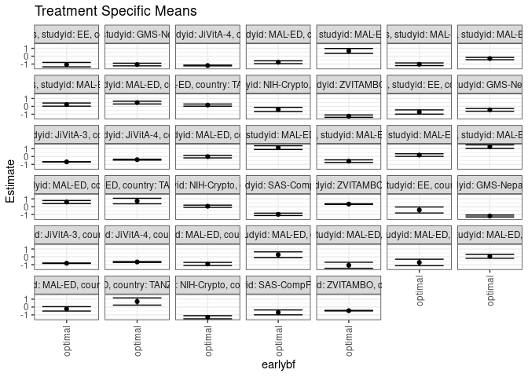

## Results Table

### Parameter: TSM

| agecat | studyid | country | intervention_level | baseline_level | estimate | ci_lower | ci_upper |
| --- | --- | --- | --- | --- | --- | --- | --- |
| Birth | EE | PAKISTAN | optimal | observed | -0.4216092 | -0.8018211 | -0.0413972 |
| Birth | GMS-Nepal | NEPAL | optimal | observed | -1.1838201 | -1.3038243 | -1.0638158 |
| Birth | JiVitA-3 | BANGLADESH | optimal | observed | -0.8126921 | -0.8454118 | -0.7799725 |
| Birth | JiVitA-4 | BANGLADESH | optimal | observed | -0.6528396 | -0.7185599 | -0.5871194 |
| Birth | MAL-ED | BANGLADESH | optimal | observed | -0.9063716 | -1.1031605 | -0.7095827 |
| Birth | MAL-ED | BRAZIL | optimal | observed | 0.2741901 | -0.0837158 | 0.6320960 |
| Birth | MAL-ED | INDIA | optimal | observed | -1.0693915 | -1.4525142 | -0.6862688 |
| Birth | MAL-ED | NEPAL | optimal | observed | -0.7155852 | -1.1274744 | -0.3036959 |
| Birth | MAL-ED | PERU | optimal | observed | 0.0744442 | -0.1795878 | 0.3284761 |
| Birth | MAL-ED | SOUTH AFRICA | optimal | observed | -0.2353485 | -0.5148887 | 0.0441917 |
| Birth | MAL-ED | TANZANIA, UNITED REPUBLIC OF | optimal | observed | 0.7006607 | 0.2418496 | 1.1594717 |
| Birth | NIH-Crypto | BANGLADESH | optimal | observed | -1.3065989 | -1.5087424 | -1.1044554 |
| Birth | SAS-CompFeed | INDIA | optimal | observed | -0.6850422 | -0.9946068 | -0.3754777 |
| Birth | ZVITAMBO | ZIMBABWE | optimal | observed | -0.4666227 | -0.5036240 | -0.4296214 |
| 6 months | EE | PAKISTAN | optimal | observed | -0.7157252 | -0.9854494 | -0.4460011 |
| 6 months | GMS-Nepal | NEPAL | optimal | observed | -0.4450047 | -0.6179190 | -0.2720905 |
| 6 months | JiVitA-3 | BANGLADESH | optimal | observed | -0.6769156 | -0.7000913 | -0.6537399 |
| 6 months | JiVitA-4 | BANGLADESH | optimal | observed | -0.3963589 | -0.4530434 | -0.3396745 |
| 6 months | MAL-ED | BANGLADESH | optimal | observed | -0.0060694 | -0.1736855 | 0.1615466 |
| 6 months | MAL-ED | BRAZIL | optimal | observed | 1.1362006 | 0.8970912 | 1.3753101 |
| 6 months | MAL-ED | INDIA | optimal | observed | -0.5872318 | -0.7564904 | -0.4179731 |
| 6 months | MAL-ED | NEPAL | optimal | observed | 0.1873848 | 0.0201181 | 0.3546515 |
| 6 months | MAL-ED | PERU | optimal | observed | 1.2585261 | 1.0380780 | 1.4789742 |
| 6 months | MAL-ED | SOUTH AFRICA | optimal | observed | 0.5894492 | 0.3960338 | 0.7828647 |
| 6 months | MAL-ED | TANZANIA, UNITED REPUBLIC OF | optimal | observed | 0.7188549 | 0.3683001 | 1.0694096 |
| 6 months | NIH-Crypto | BANGLADESH | optimal | observed | 0.0557805 | -0.0864016 | 0.1979626 |
| 6 months | SAS-CompFeed | INDIA | optimal | observed | -0.9749270 | -1.1278859 | -0.8219681 |
| 6 months | ZVITAMBO | ZIMBABWE | optimal | observed | 0.3338681 | 0.2961336 | 0.3716026 |
| 24 months | EE | PAKISTAN | optimal | observed | -1.0714183 | -1.3539413 | -0.7888953 |
| 24 months | GMS-Nepal | NEPAL | optimal | observed | -1.0561098 | -1.2229898 | -0.8892299 |
| 24 months | JiVitA-4 | BANGLADESH | optimal | observed | -1.1822881 | -1.2307732 | -1.1338029 |
| 24 months | MAL-ED | BANGLADESH | optimal | observed | -0.7656091 | -0.9452314 | -0.5859867 |
| 24 months | MAL-ED | BRAZIL | optimal | observed | 0.6720638 | 0.3590115 | 0.9851161 |
| 24 months | MAL-ED | INDIA | optimal | observed | -1.0244733 | -1.1954641 | -0.8534824 |
| 24 months | MAL-ED | NEPAL | optimal | observed | -0.2975387 | -0.4430315 | -0.1520458 |
| 24 months | MAL-ED | PERU | optimal | observed | 0.2284014 | 0.0265109 | 0.4302920 |
| 24 months | MAL-ED | SOUTH AFRICA | optimal | observed | 0.4809784 | 0.3042982 | 0.6576587 |
| 24 months | MAL-ED | TANZANIA, UNITED REPUBLIC OF | optimal | observed | 0.1625172 | 0.0245810 | 0.3004535 |
| 24 months | NIH-Crypto | BANGLADESH | optimal | observed | -0.3879533 | -0.6547383 | -0.1211682 |
| 24 months | ZVITAMBO | ZIMBABWE | optimal | observed | -1.2440344 | -1.3931962 | -1.0948726 |

### Parameter: E(Y)

| agecat | studyid | country | intervention_level | baseline_level | estimate | ci_lower | ci_upper |
| --- | --- | --- | --- | --- | --- | --- | --- |
| Birth | EE | PAKISTAN | observed | observed | -0.3522059 | -0.5428560 | -0.1615557 |
| Birth | GMS-Nepal | NEPAL | observed | observed | -1.1260580 | -1.2184297 | -1.0336863 |
| Birth | JiVitA-3 | BANGLADESH | observed | observed | -0.7778811 | -0.7969145 | -0.7588476 |
| Birth | JiVitA-4 | BANGLADESH | observed | observed | -0.6886269 | -0.7410452 | -0.6362086 |
| Birth | MAL-ED | BANGLADESH | observed | observed | -0.9390654 | -1.0847642 | -0.7933666 |
| Birth | MAL-ED | BRAZIL | observed | observed | 0.4029032 | 0.0896793 | 0.7161272 |
| Birth | MAL-ED | INDIA | observed | observed | -0.9122727 | -1.1899971 | -0.6345483 |
| Birth | MAL-ED | NEPAL | observed | observed | -0.7684615 | -1.1257770 | -0.4111460 |
| Birth | MAL-ED | PERU | observed | observed | -0.0520175 | -0.1725298 | 0.0684947 |
| Birth | MAL-ED | SOUTH AFRICA | observed | observed | -0.1690000 | -0.3880340 | 0.0500340 |
| Birth | MAL-ED | TANZANIA, UNITED REPUBLIC OF | observed | observed | 0.7624348 | 0.5710709 | 0.9537986 |
| Birth | NIH-Crypto | BANGLADESH | observed | observed | -1.2441513 | -1.3281130 | -1.1601897 |
| Birth | SAS-CompFeed | INDIA | observed | observed | -0.6676026 | -0.8422097 | -0.4929956 |
| Birth | ZVITAMBO | ZIMBABWE | observed | observed | -0.5262098 | -0.5537283 | -0.4986913 |
| 6 months | EE | PAKISTAN | observed | observed | -0.7725778 | -0.8877440 | -0.6574117 |
| 6 months | GMS-Nepal | NEPAL | observed | observed | -0.5843738 | -0.6761994 | -0.4925481 |
| 6 months | JiVitA-3 | BANGLADESH | observed | observed | -0.5935161 | -0.6130518 | -0.5739805 |
| 6 months | JiVitA-4 | BANGLADESH | observed | observed | -0.3898055 | -0.4270507 | -0.3525603 |
| 6 months | MAL-ED | BANGLADESH | observed | observed | -0.1316250 | -0.2604010 | -0.0028490 |
| 6 months | MAL-ED | BRAZIL | observed | observed | 0.9720774 | 0.8078144 | 1.1363403 |
| 6 months | MAL-ED | INDIA | observed | observed | -0.7079979 | -0.8344175 | -0.5815783 |
| 6 months | MAL-ED | NEPAL | observed | observed | 0.1104308 | -0.0208643 | 0.2417259 |
| 6 months | MAL-ED | PERU | observed | observed | 1.0528816 | 0.9313005 | 1.1744626 |
| 6 months | MAL-ED | SOUTH AFRICA | observed | observed | 0.5500267 | 0.3964966 | 0.7035568 |
| 6 months | MAL-ED | TANZANIA, UNITED REPUBLIC OF | observed | observed | 0.5362213 | 0.4049390 | 0.6675036 |
| 6 months | NIH-Crypto | BANGLADESH | observed | observed | 0.0297622 | -0.0491685 | 0.1086930 |
| 6 months | SAS-CompFeed | INDIA | observed | observed | -0.6657084 | -0.8024377 | -0.5289791 |
| 6 months | ZVITAMBO | ZIMBABWE | observed | observed | 0.3072633 | 0.2799882 | 0.3345385 |
| 24 months | EE | PAKISTAN | observed | observed | -1.0044512 | -1.1543739 | -0.8545285 |
| 24 months | GMS-Nepal | NEPAL | observed | observed | -1.1339602 | -1.2266932 | -1.0412272 |
| 24 months | JiVitA-4 | BANGLADESH | observed | observed | -1.2231088 | -1.2549632 | -1.1912543 |
| 24 months | MAL-ED | BANGLADESH | observed | observed | -0.8141706 | -0.9363085 | -0.6920327 |
| 24 months | MAL-ED | BRAZIL | observed | observed | 0.4626233 | 0.2567495 | 0.6684971 |
| 24 months | MAL-ED | INDIA | observed | observed | -0.9516520 | -1.0670654 | -0.8362385 |
| 24 months | MAL-ED | NEPAL | observed | observed | -0.3749123 | -0.4886073 | -0.2612173 |
| 24 months | MAL-ED | PERU | observed | observed | 0.1111982 | -0.0118399 | 0.2342362 |
| 24 months | MAL-ED | SOUTH AFRICA | observed | observed | 0.4152943 | 0.2928804 | 0.5377083 |
| 24 months | MAL-ED | TANZANIA, UNITED REPUBLIC OF | observed | observed | 0.0547975 | -0.0703378 | 0.1799328 |
| 24 months | NIH-Crypto | BANGLADESH | observed | observed | -0.6103502 | -0.7050157 | -0.5156847 |
| 24 months | ZVITAMBO | ZIMBABWE | observed | observed | -1.1970712 | -1.3045749 | -1.0895676 |

### Parameter: PAR

| agecat | studyid | country | intervention_level | baseline_level | estimate | ci_lower | ci_upper |
| --- | --- | --- | --- | --- | --- | --- | --- |
| Birth | EE | PAKISTAN | optimal | observed | 0.0694033 | -0.2634720 | 0.4022786 |
| Birth | GMS-Nepal | NEPAL | optimal | observed | 0.0577620 | -0.0164425 | 0.1319666 |
| Birth | JiVitA-3 | BANGLADESH | optimal | observed | 0.0348111 | 0.0064266 | 0.0631955 |
| Birth | JiVitA-4 | BANGLADESH | optimal | observed | -0.0357873 | -0.0820312 | 0.0104567 |
| Birth | MAL-ED | BANGLADESH | optimal | observed | -0.0326939 | -0.1565606 | 0.0911728 |
| Birth | MAL-ED | BRAZIL | optimal | observed | 0.1287131 | -0.1495166 | 0.4069428 |
| Birth | MAL-ED | INDIA | optimal | observed | 0.1571188 | -0.0618411 | 0.3760786 |
| Birth | MAL-ED | NEPAL | optimal | observed | -0.0528763 | -0.4239063 | 0.3181536 |
| Birth | MAL-ED | PERU | optimal | observed | -0.1264617 | -0.3494568 | 0.0965334 |
| Birth | MAL-ED | SOUTH AFRICA | optimal | observed | 0.0663485 | -0.1643144 | 0.2970114 |
| Birth | MAL-ED | TANZANIA, UNITED REPUBLIC OF | optimal | observed | 0.0617741 | -0.3306759 | 0.4542242 |
| Birth | NIH-Crypto | BANGLADESH | optimal | observed | 0.0624475 | -0.1199257 | 0.2448207 |
| Birth | SAS-CompFeed | INDIA | optimal | observed | 0.0174396 | -0.1663520 | 0.2012312 |
| Birth | ZVITAMBO | ZIMBABWE | optimal | observed | -0.0595871 | -0.0845332 | -0.0346411 |
| 6 months | EE | PAKISTAN | optimal | observed | -0.0568526 | -0.2990223 | 0.1853171 |
| 6 months | GMS-Nepal | NEPAL | optimal | observed | -0.1393690 | -0.2825708 | 0.0038327 |
| 6 months | JiVitA-3 | BANGLADESH | optimal | observed | 0.0833994 | 0.0652014 | 0.1015974 |
| 6 months | JiVitA-4 | BANGLADESH | optimal | observed | 0.0065534 | -0.0347651 | 0.0478720 |
| 6 months | MAL-ED | BANGLADESH | optimal | observed | -0.1255556 | -0.2552479 | 0.0041368 |
| 6 months | MAL-ED | BRAZIL | optimal | observed | -0.1641233 | -0.3360569 | 0.0078103 |
| 6 months | MAL-ED | INDIA | optimal | observed | -0.1207661 | -0.2603969 | 0.0188646 |
| 6 months | MAL-ED | NEPAL | optimal | observed | -0.0769540 | -0.1872826 | 0.0333746 |
| 6 months | MAL-ED | PERU | optimal | observed | -0.2056445 | -0.3852965 | -0.0259925 |
| 6 months | MAL-ED | SOUTH AFRICA | optimal | observed | -0.0394226 | -0.1931305 | 0.1142854 |
| 6 months | MAL-ED | TANZANIA, UNITED REPUBLIC OF | optimal | observed | -0.1826336 | -0.4974186 | 0.1321515 |
| 6 months | NIH-Crypto | BANGLADESH | optimal | observed | -0.0260182 | -0.1479566 | 0.0959202 |
| 6 months | SAS-CompFeed | INDIA | optimal | observed | 0.3092186 | 0.1295996 | 0.4888376 |
| 6 months | ZVITAMBO | ZIMBABWE | optimal | observed | -0.0266047 | -0.0532446 | 0.0000352 |
| 24 months | EE | PAKISTAN | optimal | observed | 0.0669671 | -0.1831554 | 0.3170896 |
| 24 months | GMS-Nepal | NEPAL | optimal | observed | -0.0778504 | -0.2208830 | 0.0651823 |
| 24 months | JiVitA-4 | BANGLADESH | optimal | observed | -0.0408207 | -0.0783429 | -0.0032985 |
| 24 months | MAL-ED | BANGLADESH | optimal | observed | -0.0485616 | -0.1758429 | 0.0787198 |
| 24 months | MAL-ED | BRAZIL | optimal | observed | -0.2094405 | -0.4121115 | -0.0067696 |
| 24 months | MAL-ED | INDIA | optimal | observed | 0.0728213 | -0.0610413 | 0.2066839 |
| 24 months | MAL-ED | NEPAL | optimal | observed | -0.0773736 | -0.1735115 | 0.0187643 |
| 24 months | MAL-ED | PERU | optimal | observed | -0.1172033 | -0.3057100 | 0.0713035 |
| 24 months | MAL-ED | SOUTH AFRICA | optimal | observed | -0.0656841 | -0.1887429 | 0.0573747 |
| 24 months | MAL-ED | TANZANIA, UNITED REPUBLIC OF | optimal | observed | -0.1077197 | -0.2061013 | -0.0093381 |
| 24 months | NIH-Crypto | BANGLADESH | optimal | observed | -0.2223969 | -0.4681797 | 0.0233858 |
| 24 months | ZVITAMBO | ZIMBABWE | optimal | observed | 0.0469632 | -0.0609126 | 0.1548390 |